# Task 3: Text Wrangling and Analysis

Germán Silva

3/8/2022

# Overview

**Summary**:

This report looks at text from the first chapter of the *Wetlands* textbook by Mitsch and Gosselink (2015). The text covers an introduction to wetland science as a concept. Text is wrangled and subset to allow for two visualizations of the most common words used throughout the text and text sentiment analysis. These two analyses allow us to understand what are the most common words and get a sense of whether the discussion of wetland science is a positive or negative topic.

**Data Citation**:

Mitsch, William and Gosselink, James. “Wetlands: Human Use and Science.” *Wetlands*, John Wiley & Sons, Inc., 2015, pp. 3 - 26.

```r
knitr::opts_chunk$set(echo = TRUE, message = FALSE, warning = FALSE)

# attach libraries
library(tidyverse)
library(tidytext)
library(textdata)
library(pdftools)
library(ggwordcloud)
```

# Most Common Words

```r
# Wrangle the data

## read in the data

wetlands <- pdf_text(here::here("data", "wetlands_chapter_1.pdf"))

## make it a data frame

wetlands_lines <- data.frame(wetlands) %>% # pdf as data frame
  mutate(page = 1:n()) %>% # added page of occurence
  mutate(text_full = str_split(wetlands, pattern = "\\n")) %>% # split lines by line breaks
  unnest(text_full) %>% # unnest lines
  mutate(text_full = str_trim(text_full)) # trim the edges

## get words from lines

wetlands_words <- wetlands_lines %>% # call in the line data
  slice(1:733) %>% # remove the reference pages from the analysis
  unnest_tokens(word, text_full) %>% # unnest the text into individual words
  select(-wetlands)

## clean the word data frame

my_stop <- data.frame(word = c("de", "al", "mitsch", "gosselink", "john", "fig", "eds", "ed", "pp", "figure", "references")) # list of words with no meaning in text such as author names, figure captions, and other similar abbreviations

wetlands_words_clean <- wetlands_words %>% # call words
  anti_join(stop_words, by = "word") %>%  # remove stop words (e.g. and, the, a, etc.)
  anti_join(my_stop, by = "word") %>%
  filter(!str_detect(word, "[0-9]")) # get rid of numbers

## get word counts

wetland_clean_counts <- wetlands_words_clean %>%
  count(word)

## Top 10 words

top_10_words <- wetland_clean_counts %>%
  arrange(-n) %>%
  slice(1:10)


## Top 100 words

top_100_words <- wetland_clean_counts %>%
  arrange(-n) %>%
  slice(1:100)
```

## Top 10 Words Visualization

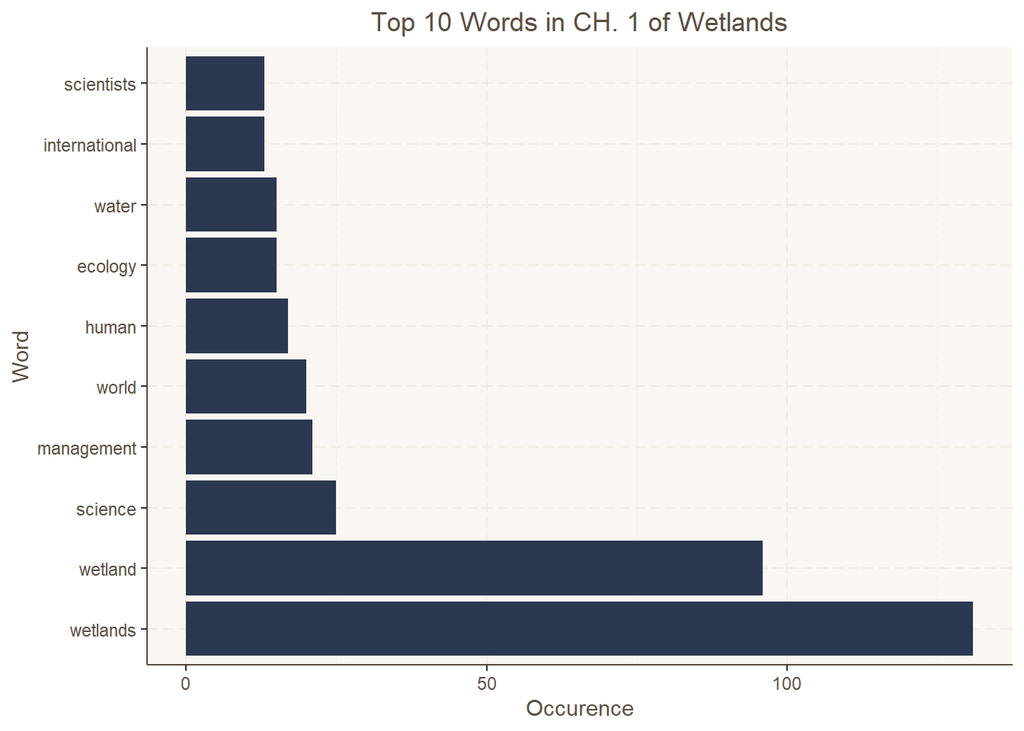

**Fig. 1** Bar graph showing the top ten words from the text. This is just one way to visualize the such data.

```r
ggplot(top_10_words, aes(x= reorder(word, -n), y= n))+
  geom_col(fill = "#2B3851")+
  ggtitle("Top 10 Words in CH. 1 of Wetlands")+
  labs(x = "Word",
       y = "Occurence")+
  theme(plot.title = element_text(color = "#5b4f41", hjust = 0.5),
            plot.background = element_rect("white"),
            panel.background = element_rect("#faf7f2"),
            panel.grid = element_line(linetype= "longdash", color = "#f0ece1"),
            axis.text = element_text(color = "#5b4f41"),
            axis.title = element_text(color = "#5b4f41"),
            strip.background = element_rect("white"),
            axis.line = element_line(color = "#5b4f41"),
            legend.position = "none")+
  coord_flip()
```

To no surprise, “wetlands” is the most common word used throughout the text and other high frequency words would be somewhat expected such as “science”, “ecology”, and “water”.

**Note**: The way that this analysis is done did not take into account plural words, so wetlands and wetland are counted as two words in the top 10 words.

## Wordcloud

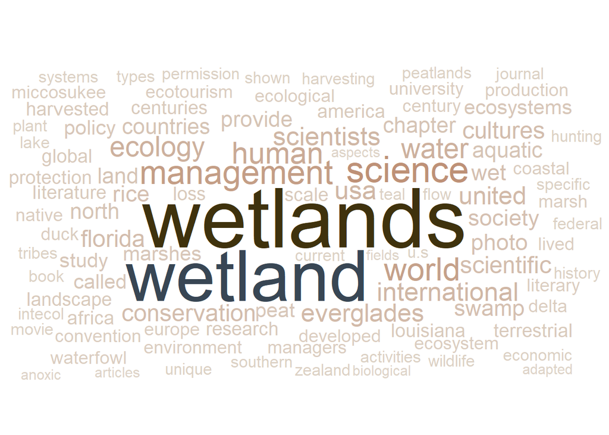

**Fig. 2** Another way to visualize text daya is a wordcloud. The above wordcloud shows the top 100 words from the text. Larger words indicate more occurences vs lighter smaller words.

```r
ggplot(top_100_words, aes(label = word))+
  geom_text_wordcloud(aes(color = n, size = n), shape = "square")+
  scale_size_area(max_size = 24)+
  scale_color_gradientn(colors = calecopal::cal_palette(name = "wetland", n= 50, type = "continuous"))+
  theme_minimal()
```

# Sentiment Analysis

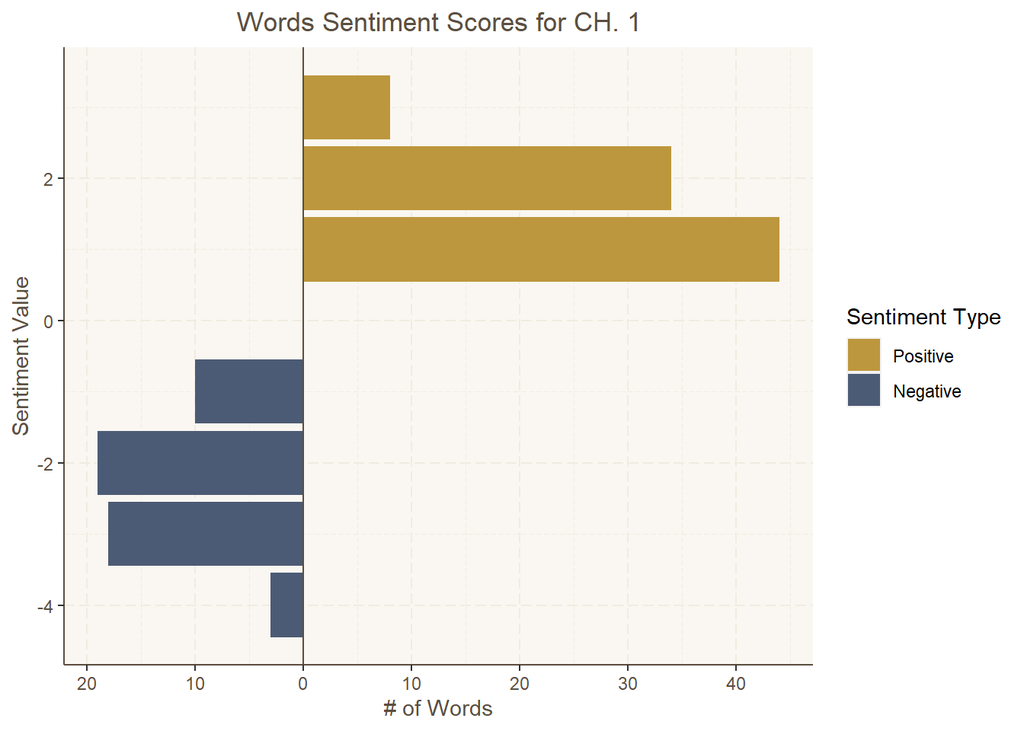

**Fig. 3** Text sentiment scores for words found throughout the chapter. A score from 1 to 5 indicates a positive sentiment, while scores from -1 to -5 indicate a negative sentiment. Overall there are more words with positive sentiments, but this does not take into account the strength of these sentiments (for example, a sentiment of +1 is not the same strength as a sentiment of -4). It seems that this introduction to wetland science is more positive than it is negative.

```r
# join sentiments from a sentiment library

wetland_afinn <- wetlands_words_clean %>%
  inner_join(get_sentiments("afinn"), by = "word") %>%
  count(value) %>%
  mutate(n = ifelse(
    value %in% c(-4, -3, -2, -1), n * -1, n),
    affinity = ifelse(value %in% c(-4, -3, -2, -1), "Negative", "Positive"))

# make a plot of sentiment affinity

ggplot(wetland_afinn, aes(x = value, y = n, fill = affinity)) +
  geom_bar(stat = "identity", position = "identity")+
  geom_hline(yintercept = 0, color = "#5b4f41")+
  ggtitle("Words Sentiment Scores for CH. 1")+
  scale_y_continuous(breaks = pretty(wetland_afinn$n), labels = abs(pretty(wetland_afinn$n)))+
  scale_fill_manual(values = c("Positive" = "#bd973d",
                               "Negative" = "#4c5b75"))+
  labs(x = "Sentiment Value",
       y = "# of Words",
       fill = "Sentiment Type")+
   theme(plot.title = element_text(color = "#5b4f41", hjust = 0.5),
            plot.background = element_rect("white"),
            panel.background = element_rect("#faf7f2"),
            panel.grid = element_line(linetype= "longdash", color = "#f0ece1"),
            axis.text = element_text(color = "#5b4f41"),
            axis.title = element_text(color = "#5b4f41"),
            strip.background = element_rect("white"),
            axis.line = element_line(color = "#5b4f41")) +
  coord_flip()
```